# Congenital Sucrase-Isomaltase Deficiency: Heterogeneity of I... : Journal of Pediatric Gastroenterology and Nutrition

Articles

[November 2012 - Volume 55 - Issue](https://journals.lww.com/jpgn/toc/2012/11002)

Supplement Articles

# Congenital Sucrase-Isomaltase Deficiency

## Heterogeneity of Inheritance, Trafficking, and Function of an Intestinal Enzyme Complex

Naim, Hassan Y.*; Heine, Martin*; Zimmer, Klaus-Peter†

Author Information

Journal of Pediatric Gastroenterology and Nutrition [55():p S13-S20, November 2012.](https://journals.lww.com/jpgn/toc/2012/11002) | DOI: 10.1097/01.mpg.0000421402.57633.4b

- Free

Brush border membranes are the largest exposed surfaces in tissues. They constitute the interface between the “milieu exterieur” and the “milieu interieur” of the body in a variety of organs such as the gastrointestinal tract and bile canaliculi, where hydrolytic, absorptive, and secretory processes take place. The intestinal mucosa is the exclusive site for nutrient metabolism and subsequent uptake of the generated products, such as monosaccharides and amino acids. The hydrolysis and absorption of micronutrients are achieved by the concerted action of hydrolases and transporters that are predominantly located in the brush border membranes (BBMs) <sup>(1)</sup>.

The hydrolases are divided into 2 major families, the peptidases and the disaccharidases <sup>(2)</sup>. The peptidases, such as aminopeptidases N (CD13), A, and W, carboxypeptidases P and M, dipeptidylpeptidase IV, or α-glutamyl transpeptidase, are expressed in many tissues, including the intestine and the kidney <sup>(3,4)</sup>. The expression of many of the disaccharidases, by contrast, is limited to the intestinal BBM. Prominent members of this family are the enzymes sucrase-isomaltase (SI) <sup>(5)</sup>, maltase-glucoamylase <sup>(6)</sup>, and lactase-phlorizin hydrolase <sup>(7)</sup>. SI and maltase-glucoamylase hydrolyze α-glycosidically linked starch, glycogen, sucrose, and maltose. The generated monosaccharides are eventually transported across the BBM of epithelial cells into the cell interior. Another major brush border disaccharidase is lactase-phlorizin hydrolase, which cleaves β-glycosidic linkage in lactose, the main carbohydrate in mammalian milk that constitutes the primary diet source for newborns <sup>(8)</sup>. Several other glycosidases with similar enzymatic specificities toward cleaving α- or β-glycosidic linkages exert their function in intracellular compartments, such as the lysosomes. Examples of this group of carbohydrases are lysosomal α-glucosidase <sup>(9)</sup>, β-glucosidase <sup>(10)</sup>, and α-galactosidase <sup>(11)</sup> or glycosidases of the glycogen catabolism.

Pathological conditions, most notably malabsorption of disaccharides and the subsequent symptoms, are associated with the absence of these enzymes in the intestinal lumen. Examples of these disorders are congenital SI deficiency (CSID), adult-type hypolactasia, congenital lactase deficiency, secondary lactase deficiency, and maltase-glucoamylase deficiency. This review focuses on the structural and biosynthetic features of SI and the molecular basis of sugar malabsorption in CSID. The diversity and heterogeneity of this disease is reflected in the existence of several mutant phenotypes of SI that vary in their posttranslational processing, cellular localization, and function. The pathogenetic mechanisms of CSID are unique for intestinal malabsorption disorders and have implications for the pathobiology of the intestinal mucosa. Unraveling the molecular basis of this disease revealed novel mechanisms of protein trafficking and polarized sorting.

## PATHOPHYSIOLOGY, CLINICAL FEATURES, AND DIAGNOSIS OF CSID

CSID is an autosomal recessive intestinal disorder that was first described by Weijers et al in 1960 <sup>(12)</sup>. It arises from mutations in the intestinal brush border enzyme complex SI. CSID occurs in 0.2% of individuals of European descent <sup>(13)</sup> and approximately 5% in indigenous Greenlanders <sup>(14)</sup>. Heterozygotes with normal small intestinal morphology and with sucrase activity level below the lower limit for the normal population represent approximately 2% to 9% of Americans of European descent <sup>(15,16)</sup>.

SI comprises 2 activities: sucrase that hydrolyzes α-1,2- and α-1,4-glucosidic bonds and isomaltase that cleaves α-1,6 linkages. The sucrase activity overlaps with that of intestinal maltase-glucoamylase, which digests α-1,4-glucosidic linkages of the end and intermediary product of α-amylolysis of starches such as maltose, maltotriose and low- and high-molecular-weight branched dextrins.

Patients with CSID experience vomiting, osmotic diarrhea, mild steatorrhea, chronic diarrhea, and crying spells upon ingestion of sugars <sup>(17)</sup>. Occasionally dehydration, failure to thrive, developmental retardation, and muscular hypotonia were observed, which were compatible with broad clinical heterogeneity <sup>(13,18)</sup>. CSID also has been reported to be associated with nephrocalcinosis, renal calculi, metabolic acidosis, and hypercalcemia <sup>(19,20)</sup>. The clinical heterogeneity is supported by the findings that diverse mutant phenotypes of SI are responsible for the onset of CSID.

Several factors contribute to the development and extent of symptoms in patients with CSID: residual enzymatic activities of sucrase and isomaltase, amount of fed carbohydrate (in association with other foods), gastric emptying, small-bowel transit, degree of fermentation of unabsorbed carbohydrates by colonic bacteria, and absorption of the colon. Furthermore, the CSID symptoms also depend on the patient's age. Symptoms, and particularly starch tolerance, spontaneously improve with age. Onset of symptoms in adulthood with diagnosis up to age 59 years has been reported <sup>(19,21,22)</sup>.

The diagnosis of CSID is often delayed or perhaps missed because the symptoms are erroneously recognized as being related to diseases such as cystic fibrosis and celiac disease or to other causes of recurrent diarrhea and food allergy. A major step in diagnosing CSID is to recognize the complaints and clinical features of the patients in relation to age-dependent alterations and composition of nutrition. An increase in blood glucose of <20 mg/dL after a 2.0-g/kg sucrose load as well as an increase in breath hydrogen are compatible with sucrose intolerance <sup>(23–25)</sup>.

The diagnosis of CSID requires the determination of SI activity in mucosa with normal histology. Enterocytes of patients with CSID lack the sucrase activity of the enzyme SI, whereas the isomaltase activity can vary from absent to practically normal. The disaccharidase activities in the duodenum are reduced by almost 40% as compared with the proximal jejunum <sup>(25,26)</sup>. In some SI-deficient patients, the activity of maltase-glucoamylase is reduced, as is the isomaltase activity <sup>(27)</sup>. The activities of other brush border disaccharidases such as lactase-phlorizin hydrolase and maltase-glucoamylase and peptidases such as aminopeptidase N, dipeptidyl peptidase IV, and meprin are usually within the normal range.

## THERAPY OF CSID

Lifelong sucrose restriction is an effective therapeutic option for patients with CSID. The degree of restriction, however, depends on the individual complaints of a patient because patients with CSID show variable tolerances toward sucrose. Sucrose concentrations between 3 and 6 g/100 g in nutrients (onion, honey, soybean flour) are considered to be high. In many cases of CSID the isomaltase activity is also affected. Therefore, the diet of patients with CSID should also exclude starch and glucose polymers, such as wheat and potatoes. *Saccharomyces cerevisiae* possesses sucrase activity and a low isomaltase and maltase activity and can be used in CSID therapy. The use of lyophilized preparations of *S cerevisiae* reduced hydrogen excretion by 70%, with loss or reduction of clinical symptoms in CSID <sup>(28,29)</sup>. Sacrosidase or invertase (Sucraid), a liquid preparation produced from *S cerevisiae,* has been used successfully in the treatment of patients with CSID <sup>(30)</sup>.

## STRUCTURAL FEATURES AND TRAFFICKING OF SI

SI is a type II integral membrane glycoprotein that is exclusively expressed in the small intestinal microvillus membrane and is responsible for the terminal digestion of dietary sucrose and starch. The glycoprotein comprises 2 subunits that are highly homologous and are thought to be derived from the same ancestral gene <sup>(31,32)</sup>. These 2 subunits are associated with each other by strong noncovalent, ionic interactions <sup>(33)</sup>. SI is synthesized in the rough endoplasmic reticulum (ER) as a single-chain mannose-rich precursor comprising both subunits (pro-SI<sub>h</sub>, 210 kDa) <sup>(5)</sup> (Fig. 1). It is transported to the Golgi apparatus at a relatively slow rate and does not form homodimers before ER exit <sup>(5,34)</sup>. The strong homologies between the 2 main domains suggest that quasidimers or pseudodimers are formed, which are presumably sufficient for the acquisition of transport competence from the ER to the Golgi apparatus and further to the cell surface. After modification of the N-linked glycans and O-glycosylation in the Golgi apparatus, SI is sorted to the apical membrane with high fidelity. In fact, 90% to 95% of the de novo synthesized protein is transported to the apical membrane. In the apical membrane pro-SI is cleaved in situ by luminal pancreatic proteases to its 2 active subunits, sucrase and isomaltase <sup>(33)</sup>. On its way to the apical membrane, SI associates with cholesterol- and sphingolipid-enriched membrane microdomains (lipid rafts), which act as platforms to warrant an efficient sorting of SI <sup>(35)</sup>. Interestingly, the association of SI with lipid rafts substantially increases the activity of sucrase and isomaltase by a factor of almost 3-fold <sup>(36)</sup>.

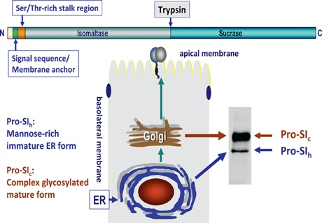

FIGURE 1:

Pro-sucrase-isomaltase (1827 amino acids).

## MOLECULAR BASIS OF CSID

Conformational modifications of membrane and secretory proteins commence during their translocation across the ER membrane and continue in the ER lumen (Fig. 1). Cotranslational glycosylation <sup>(37)</sup>, intermolecular or intramolecular disulfide bond formation <sup>(38)</sup>, and subunit assembly or oligomerization are examples of early modifications directly implicated in the protein maturation events, and are rate limiting along the exocytic pathway <sup>(39)</sup>. Further posttranslational modifications in the Golgi apparatus, such as acquisition of a complex type of N-linked glycans and O-glycosylation <sup>(37)</sup>, also affect protein trafficking to the cell surface and secretion into the external milieu and polarized protein sorting in epithelial cells.

The dissection of molecular mechanisms required for efficient cellular transport of membrane and secretory proteins to the cell surface has greatly benefited from molecular analyses of genetic diseases directly associated with misfolded proteins and impaired protein targeting. Examples of these diseases are cystic fibrosis (CFTR protein) <sup>(40)</sup>, familial hypercholesterolemia (low-density lipoprotein receptor) <sup>(41)</sup>, Wilson disease (a P-type adenosine triphosphatase) <sup>(42)</sup>, nephrogenic diabetes insipidus (aquaporin 2) <sup>(43)</sup>, Liddell's syndrome (amilroide-sensitive epithelial Na<sup>+</sup> channel) <sup>(44,45)</sup>, and CSID (intestinal SI) <sup>(13)</sup>.

Early research on the molecular basis of CSID has suggested the presence of an enzymatically inactive SI in CSID <sup>(46,47)</sup>. Hauri et al demonstrated a trafficking defect and an intracellular accumulation of SI in the *trans*-Golgi as an underlying cause of CSID <sup>(48)</sup>.

In a multicenter collaborative study, biopsy specimens from patients with CSID were analyzed at the biochemical and cellular levels <sup>(49)</sup>. The study defined CSID as a heterogeneous carbohydrate malabsorption disorder that exists in several phenotypes relevant to altered trafficking, cellular localization, or function of SI (Table 1). This study further proposed that the CSID phenotypes are elicited by different mutations in the coding region of the SI gene. In fact, the first successful cloning and characterization of a cDNA-encoding SI from a biopsy sample of a patient with CSID led to the identification of a point mutation that is responsible for the impaired intracellular transport behavior of SI <sup>(50)</sup>. In the meantime, the mutations and their consequences on the trafficking and function of SI in 7 different phenotypes of CSID have been identified (Table 1, Figs. 2 and 3) <sup>(48,49,51)</sup>. A survey of the features of the individual phenotypes follows.

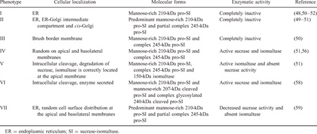

TABLE 1:

Naturally occurring phenotypes of congenital sucrase-isomaltase deficiency

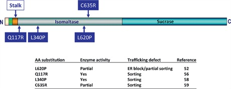

FIGURE 2:

Isomaltase-based mutations in CSID.

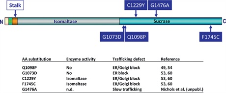

FIGURE 3:

Sucrase-based mutations in CSID.

### Phenotypes of SI in CSID

#### SI Is Blocked in the *cis*-Golgi Compartment and the ER/*cis*-Golgi Intermediate Compartment (ERGIC) in Phenotype II

The phenotype II of CSID is characterized by an intracellular block of SI in the ER, the ERGIC, and the *cis*-Golgi <sup>(49,50)</sup>. As in phenotype I, the enzymatic activities of sucrase and isomaltase are below detection limit. This phenotype was the first in which a mutation in the SI gene has been identified and resulted in a substitution of a glutamine by a proline in the sucrase subunit of SI at amino acid 1098 (Q1098P) <sup>(50)</sup>. In this phenotype, the mutant SI (Q1098P) retains its mannose-rich form and is ultimately degraded during prolonged chase time points. In confocal analyses, a YFP-tagged chimera of mutant SI (Q1098P) is predominantly located in the ER and in the Golgi. The Q1098P exchange confers temperature sensitivity on mutant SI <sup>(54)</sup>. In fact, correct folding, full enzymatic activity, and competent intracellular transport can be partially restored by expression of the mutant SI (Q1098P) at the permissive temperature of 20°C instead of 37°C. Restoring function and normal trafficking and function is associated with several cycles of anterograde and retrograde steps between the ER and the Golgi, implicating the molecular chaperones calnexin and BiP, the immunoglobulin heavy chain-binding protein <sup>(54)</sup>. This SI phenotype is the first of its kind in an intestinal disease that implicates a temperature-sensitive mutation. The Q1098P substitution is located in a region of the sucrase subunit (Fig. 3) that shares striking similarities with the isomaltase subunit and other functionally related enzymes, such as human lysosomal α-glucosidase and glucoamylase of the yeast *Schwanniomyces occidentalis*<sup>(32)</sup>. Introduction of this mutation into the homologous region of lysosomal α-glucosidase elicited similar cellular and biochemical characteristics to phenotype II of SI. A likely proposal is that Q1098P is a part of a motif within SI that leads to a retention of SI in the *cis*-Golgi within the framework of a quality-control machinery that operates in the intermediate compartment or *cis*-Golgi <sup>(54)</sup>. A potential phenylalanine-rich motif, F(1093)-X-F(1095)-X-X-Q-F(1099) (X could be any amino acid), that flanks the Q1098 residue has been suggested to be implicated in sensing the folding and subsequent trafficking of SI from the ER to the Golgi <sup>(55)</sup>. The phenylalanine cluster in this motif is most likely required for shielding a folding determinant in the extracellular domain of SI, whereby substitution of a Q by a P at residue 1098 of sucrase disrupts this determinant and elicits retention of SI(Q1098P) in ERGIC and *cis*-Golgi in phenotype II of CSID (Table 1).

#### Random Delivery of SI to the Apical and the Basolateral Membranes Characterize Phenotype IV

SI is targeted with high fidelity to the BBM in intestinal epithelial cells (95%) <sup>(35)</sup>, where it exerts its digestive function (Table 1). Impaired trafficking of SI would, therefore, be associated with malabsorption because of reduced levels of the enzyme in the BBM. Analysis of 2 cases of CSID using immunoelectron microscopy demonstrated an altered distribution of SI from an exclusive apical to a random localization at the apical and basolateral membranes <sup>(51,56)</sup>. This phenotype is elicited by the amino acid substitution of glutamine to arginine at residue 117 (Q117R) in the isomaltase subunit (Fig. 2) that is located in close proximity to the O-glycosylated stalk domain that is implicated in the sorting of SI. In wild-type SI, the stalk domain itself is directly involved in targeting the SI molecule to the apical membrane through an interaction of its O-glycosylated carbohydrate content with a putative lectin receptor that recruits SI to detergent-insoluble cholesterol/sphingolipid-rich lipid microdomains (lipid rafts) <sup>(35)</sup>. It is likely, therefore, that the Q117R mutation generates a misfolded determinant near the stalk region leading to an inadequate recognition of the O-glycosylated stalk in SI by such a putative lectin-like sorting receptor or an O-glycan receptor. This CSID phenotype provides an exquisite model to be used in resolving the identity of this putative receptor.

#### Intracellular Proteolytic Cleavage of SI at 2 Different Sites in Phenotypes V and VI

Human SI is transported to the BBM as a single-chain polypeptide, pro-SI, that is cleaved in the intestinal lumen by pancreatic trypsin to isomaltase and sucrase <sup>(5)</sup>. In phenotype V, the pro-SI precursor is intracellularly cleaved in the *trans*-Golgi network (TGN), whereby the sucrase subunit is degraded and the isomaltase subunit is properly transported per se to the apical membrane <sup>(51)</sup>. This phenotype of CSID provided the first indication that isomaltase contains all of the necessary information required for apical transport of SI (Fig. 2). Later, this hypothesis was experimentally verified and the signals for apical sorting were identified in the O-glycosylated stalk region and the membrane anchoring domain; both domains are located in the isomaltase subunit <sup>(35,57)</sup>.

Cleavage of mutant SI in the ER occurs in phenotype VI <sup>(58)</sup>, which is elicited by a point mutation in the isomaltase subunit that converts a leucine to proline at residue 340 (Table 1, Fig. 2) (L340P). Interestingly, cleaved SI is transported efficiently along the secretory pathway, processed in the Golgi apparatus, and ultimately secreted into the exterior milieu as an active enzyme. The pathogenetic mechanism underlying CSID here is elicited by the conversion of an integral membrane glycoprotein into a secreted protein that cannot exert its function in the BBM.

#### Altered Folding, Increased Turnover, and Partial Missorting Characterize Phenotype VII

Another mutation relevant to polarized sorting of SI to the apical membrane has been identified in CSID. This mutation, C635R, is located in the isomaltase subunit and has been shown to confer partial missorting of mutant SI to the basolateral membrane <sup>(59)</sup>. It eliminates a disulfide bond and subsequently alters a protein determinant in isomaltase that is presumably important for fine tuning of the apical sorting signal of SI. Expression of mutant SI (C635R) in a mammalian cell line revealed an altered folding pattern with subsequent retarded intracellular transport, increased turnover rate, and an aberrant transport of mutant SI to the apical membrane (Fig. 2). Concomitant with the altered sorting pattern, the mode of association of mutant SI with the membrane is altered and the protein shifts from a partially soluble protein with Triton X-100 that is associated with lipid rafts <sup>(35)</sup> to a completely Triton X-100–soluble protein. The mutation has therefore affected an epitope implicated in the apical targeting fidelity of SI. Altogether, the combined effects of the C635R mutation on the turnover rate, function, polarized sorting, and detergent solubility of SI constitute a unique and novel pathomechanism of CSID.

## COMPOUND HETEROGENOUS MUTATIONS

Although our initial knowledge of the molecular pathogenesis of CSID came from cases in which patients were homozygous for single mutations in the SI gene, a screen of a cohort of patients in Hungary with typical symptoms of disaccharide malabsorption has surprisingly suggested compound heterozygosity in several patients with CSID <sup>(60)</sup>. Molecular analyses at the cellular and molecular levels of several of the newly discovered mutations confirmed that the single mutations on the individual alleles act in concert to elicit CSID <sup>(53)</sup>. Here, 2 major groups of heterozygous mutations were characterized that resulted in the amino acid substitutions V577G and G1073D in 1 patient and C1229Y and F1745C in another. These individual mutations resulted in an intracellular block of SI in the ER (mutations V577G, G1073D, and F1745C) or in the Golgi apparatus (C1229Y). It is obvious, therefore, that each of the mutations per se could have elicited CSID if it occurred in a homozygous context. The locations of the individual mutations in various domains of sucrase or isomaltase raise the possibility that an altered folding of a particular domain of sucrase or isomaltase caused by an individual mutation could be compensated by the unaffected one of the protein product of the second allele in the same patient. If this is the case, then the consequence could be an interaction of the SI mutants of both alleles generating a new phenotype that differs at the functional and cell biological levels from the individual phenotypes. Such an interactive mechanism would modify the severity of the SI deficiency. This hypothetical concept was not supported experimentally, however, because coexpression of 2 mutants derived from 1 patient did not change the phenotype or function as compared with the individual mutants.

## CLASSIFICATION OF THE MUTATIONS IN THE SI GENE BASED ON THEIR SUBUNIT LOCALIZATION AND TRAFFICKING RELEVANCE

The role of the sucrase subunit can be seen at the level of the ER to Golgi trafficking of SI. It acts perhaps as a shuttle that carries the isomaltase to the apical membrane. This is clearly demonstrated in the SI mutants containing the mutations C1229Y and F1745C <sup>(53)</sup> (Fig. 3) in which isomaltase persists as a correctly folded protein, whereas the mutations elicit malfolded conformation of sucrase. That a correctly folded and an enzymatically active isomaltase are not capable per se of being targeted to the apical membrane strongly suggests a chaperoning function of sucrase within SI through which an interaction between sucrase and isomaltase is required in the intracellular transport of SI. Other sucrase-based mutations such as Q1098P and G1073D support this view. An abolition of sucrase enzymatic activity reduces the activity of isomaltase by approximately 60%, suggesting a cooperative effect of intact sucrase and isomaltase in exerting optimal activities of the enzyme complex <sup>(53)</sup>.

SI associates with vesicular carriers that contain protein components such as annexin II, myosin Ia, and lymphocyte-associated α-kinase <sup>(73–75)</sup>. Annexin II is particularly important because its downregulation not only leads to accumulation of SI in intracellular compartments of MDCK cells but also changes the morphology if downregulated in intestinal Caco-2 cells. Here, long-term downregulation of annexin II leads to dramatic alterations in the apical membrane, as revealed by flattened surface and substantial reduction in the number of microvilli <sup>(76)</sup>.

## NOVEL CONCEPTS OF CSID INHERITANCE AND PREVALENCE

Compound heterozygosity has been demonstrated in several recessively inherited diseases such as cystic fibrosis, factor X deficiency, or familial Mediterranean fever <sup>(77–80)</sup>, and CSID can now be added to this list as the first intestinal disaccharidase disorder with this pattern of inheritance. It is interesting to note that the normal activity levels of the disaccharidases SI, maltase-glucoamylase, and lactase-phlorizin hydrolase display a wide range <sup>(81,82)</sup>, in which the maximum levels are more than 2-fold higher than the minimal normal levels. These activity levels may be explained by a genetic pattern of SI that correlates with 1 healthy allele for the “low normal activity” and 2 healthy alleles for the “high normal activity.” Consequently, it is likely that coding or noncoding regulatory mutations in these genes may be more common than initially thought and that the effects elicited by these mutations are compensated for by the wild-type alleles. Along these lines, it is likely that CSID does not arise as a consanguineous trait as was initially thought, whereby 2 alleles are defective, and it is likely to be more common instead.

## CONCLUSIONS

Elucidation of pathomechanisms implicating impaired protein transport and altered intracellular processing in many diseases has greatly advanced our knowledge of the corresponding mechanisms and their protein and structural components. We presented cases of a mild intestinal brush border disease, CSID, through which several aspects of the trafficking between the ER and the Golgi apparatus, as well as the polarized apical sorting, have been defined and identified.

A novel quality-control mechanism has been proposed by phenotype II in which a temperature-sensitive mutant SI is synthesized and processed between the ER and *cis*-Golgi. It remains to be elucidated whether this quality-control machinery is limited to SI and structurally similar proteins or a ubiquitous network whose components have yet to be identified.

The sorting phenotypes IV to VI helped localize apical sorting signals of SI to O-glycosylation (stalk region) and the transmembrane domain and have unequivocally demonstrated that an active recognition of O-glycans, perhaps through a lectin-like receptor, is required for association of SI with lipid rafts. One main criterion of these sorting mechanisms is the association or nonassociation of the proteins with detergent-insoluble lipid microdomains (rafts) rich in cholesterol and glycosphingolipids.

Furthermore, proteins could be identified that were specifically involved in the peripheral distribution of the rafts-associated SI along actin filaments versus nonassociated lactase-phlorizin hydrolase, thus suggesting a mechanism in which annexin II interacts with the vesicle membrane and the cytoskeleton and lymphocyte-associated α-kinase activates the actin motor protein myosin Ia.

The pattern of inheritance of CSID is either based on single mutations on both alleles (homozygous pattern) or caused by compound heterozygosity, thus suggesting that CSID is a more common disease than initially thought. It is important to note that that all of the patients described in this review have essentially similar clinical symptoms, yet with different mutations in the sucrase or isomaltase coding regions. Nevertheless, a reliable correlation between the genotype/phenotype and variations in the clinical symptoms requires a higher sample number, to which none of the studies described so far had access. The progress in unraveling the molecular basis of CSID constitutes a strong asset for developing novel therapies in which protein components implicated in the onset of the disease could be targeted, rather than lifelong sucrose-prevention treatment. Along this line, it would be interesting to identify the genetics of CSID in the population of Greenland, where the incidence of CSID accounts for almost 5% of the entire population, and to determine whether CSID is elicited by novel mutations specific for this ethnic group. Finally, there are few reports on the onset of CSID in adults <sup>(21,83)</sup>. In 1 case, however, the deficiency was the consequence of severe dietary carbohydrate restriction <sup>(21)</sup>. Nevertheless, characterization of the genetic background of these rare cases and their comparison with the known mutations could shed light on the functionality of particular mutations in the context of long-term progression of carbohydrate malabsorption.

### Acknowledgments

We are indebted to the excellent assistance and input of members of our laboratories, whose contributions are cited where appropriate.

## REFERENCES

1. Wright EM, Loo DD, Panayotova-Heiermann M, et al. “Active” sugar transport in eukaryotes. *J Exp Biol* 1994; 196:197–212.

2. Webb EC. *Enzyme Nomenclature: Recommendations of the NCIUBMB on the Nomenclature and Classification of Enzymes*. San Diego: Academic Press; 1992.

3. Matter K, Brauchbar M, Bucher K, et al. Sorting of endogenous plasma membrane proteins occurs from two sites in cultured human intestinal epithelial cells (Caco-2). *Cell* 1990; 60:429–437.

4. Olsen J, Cowell GM, Konigshofer E, et al. Complete amino acid sequence of human intestinal aminopeptidase N as deduced from cloned cDNA. 1988; 238:307–314.

5. Naim HY, Sterchi EE, Lentze MJ. Biosynthesis of the human sucrase-isomaltase complex. Differential O-glycosylation of the sucrase subunit correlates with its position within the enzyme complex. 1988; 263:7242–7253.

6. Naim HY, Sterchi EE, Lentze MJ. Structure, biosynthesis, and glycosylation of human small intestinal maltase-glucoamylase. 1988; 263:19709–19717.

7. Naim HY, Sterchi EE, Lentze MJ. Biosynthesis and maturation of lactase-phlorizin hydrolase in the human small intestinal epithelial cells. 1987; 241:427–434.

8. Doell RG, Kretchmer N. Studies of small intestine during development. I. Distribution and activity of beta-galactosidase. 1962; 62:353–362.

9. Hermans MM, Kroos MA, van Beeumen J, et al. Human lysosomal alpha-glucosidase. Characterization of the catalytic site. 1991; 266:13507–13512.

10. Tsuji S, Choudary PV, Martin BM, et al. Nucleotide sequence of cDNA containing the complete coding sequence for human lysosomal glucocerebrosidase. 1986; 261:50–53.

11. Kornreich R, Desnick RJ, Bishop DF. Nucleotide sequence of the human alpha-galactosidase A gene. 1989; 17:3301–3302.

12. Weijers HA, va de KJ, Mossel DA, et al. Diarrhoea caused by deficiency of sugar-splitting enzymes. 1960; 2:296–297.

13. Treem WR. Congenital sucrase-isomaltase deficiency. 1995; 21:1–14.

14. Gudmand-Hoyer E, Fenger HJ, Kern-Hansen P, et al. Sucrase deficiency in Greenland. Incidence and genetic aspects. 1987; 22:24–28.

15. Welsh JD, Poley JR, Bhatia M, et al. Intestinal disaccharidase activities in relation to age, race, and mucosal damage. 1978; 75:847–855.

16. Peterson ML, Herber R. Intestinal sucrase deficiency. 1967; 80:275–283.

17. Gudmand-Hoyer E, Krasilnikoff PA. The effect of sucrose malabsorption on the growth pattern in children. 1977; 12:103–107.

18. Antonowicz I, Lloyd-Still JD, Khaw KT, et al. Congenital sucrase-isomaltase deficiency. Observations over a period of 6 years. 1972; 49:847–853.

19. Starnes CW, Welsh JD. Intestinal sucrase-isomaltase deficiency and renal calculi. 1970; 282:1023–1024.

20. Belmont JW, Reid B, Taylor W, et al. Congenital sucrase-isomaltase deficiency presenting with failure to thrive, hypercalcemia, and nephrocalcinosis. 2002; 2:4.

21. Cooper BT, Scott J, Hopkins J, et al. Adult onset sucrase-isomaltase deficiency with secondary disaccharidase deficiency resulting from severe dietary carbohydrate restriction. 1983; 28:473–477.

22. Neale G, Clark M, Levin B. Intestinal sucrase deficiency presenting as sucrose intolerance in adult life. 1965; 2:1223–1225.

23. Ford RP, Barnes GL. Breath hydrogen test and sucrase isomaltase deficiency. 1983; 58:595–597.

24. Perman JA, Barr RG, Watkins JB. Sucrose malabsorption in children: noninvasive diagnosis by interval breath hydrogen determination. 1978; 93:17–22.

25. Rana SV, Bhasin DK, Katyal R, et al. Comparison of duodenal and jejunal disaccharidase levels in patients with non ulcer dyspepsia. 2001; 22:135–136.

26. Smith JA, Mayberry JF, Ansell ID, et al. Small bowel biopsy for disaccharidase levels: evidence that endoscopic forceps biopsy can replace the Crosby capsule. 1989; 183:317–321.

27. Skovbjerg H, Krasilnikoff PA. Maltase-glucoamylase and residual isomaltase in sucrose intolerant patients. 1986; 5:365–371.

28. Treem WR, Ahsan N, Sullivan B, et al. Evaluation of liquid yeast-derived sucrase enzyme replacement in patients with sucrase-isomaltase deficiency. 1993; 105:1061–1068.

29. Treem WR, McAdams L, Stanford L, et al. Sacrosidase therapy for congenital sucrase-isomaltase deficiency. 1999; 28:137–142.

30. Lucke T, Keiser M, Illsinger S, et al. Congenital and putatively acquired forms of sucrase-isomaltase deficiency in infancy: effects of sacrosidase therapy. 2009; 49:485–487.

31. Hunziker W, Spiess M, Semenza G, et al. The sucrase-isomaltase complex: primary structure, membrane-orientation, and evolution of a stalked, intrinsic brush border protein. 1986; 46:227–234.

32. Naim HY, Niermann T, Kleinhans U, et al. Striking structural and functional similarities suggest that intestinal sucrase-isomaltase, human lysosomal alpha-glucosidase and Schwanniomyces occidentalis glucoamylase are derived from a common ancestral gene. 1991; 294:109–112.

33. Hauri HP, Quaroni A, Isselbacher KJ. Biogenesis of intestinal plasma membrane: posttranslational route and cleavage of sucrase-isomaltase. 1979; 76:5183–5186.

34. Hauri HP, Sterchi EE, Bienz D, et al. Expression and intracellular transport of microvillus membrane hydrolases in human intestinal epithelial cells. 1985; 101:838–851.

35. Alfalah M, Jacob R, Preuss U, et al. O-linked glycans mediate apical sorting of human intestinal sucrase-isomaltase through association with lipid rafts. 1999; 9:593–596.

36. Wetzel G, Heine M, Rohwedder A, et al. Impact of glycosylation and detergent-resistant membranes on the function of intestinal sucrase-isomaltase. 2009; 390:545–549.

37. Kornfeld R, Kornfeld S. Assembly of asparagine-linked oligosaccharides. 1985; 54:631–664.

38. Gething MJ, Sambrook J. Protein folding in the cell. 1992; 355:33–45.

39. Palade G. Intracellular aspects of the process of protein synthesis. 1975; 189:867.

40. Quinton PM. Chloride impermeability in cystic fibrosis. 1983; 301:421–422.

41. Goldstein JL, Brown MS. Familial hypercholesterolemia: identification of a defect in the regulation of 3-hydroxy-3-methylglutaryl coenzyme A reductase activity associated with overproduction of cholesterol. 1973; 70:2804–2808.

42. Langner C, Denk H. Wilson disease. 2004; 445:111–118.

43. Morello JP, Bichet DG. Nephrogenic diabetes insipidus. 2001; 63:607–630.

44. Hiltunen TP, Hannila-Handelberg T, Petajaniemi N, et al. Liddle's syndrome associated with a point mutation in the extracellular domain of the epithelial sodium channel gamma subunit. 2002; 20:2383–2390.

45. Kyuma M, Ura N, Torii T, et al. A family with Liddle's syndrome caused by a mutation in the beta subunit of the epithelial sodium channel. 2001; 23:471–478.

46. Dubs R, Steinmann B, Gitzelmann R. Demonstration of an inactive enzyme antigen in sucrase-isomaltase deficiency. 1973; 28:187–198.

47. Freiburghaus AU, Dubs R, Hadorn B, et al. The brush border membrane in hereditary sucrase-isomaltase deficiency: abnormal protein pattern and presence of immunoreactive enzyme. 1977; 7:455–459.

48. Hauri HP, Roth J, Sterchi EE, et al. Transport to cell surface of intestinal sucrase-isomaltase is blocked in the Golgi apparatus in a patient with congenital sucrase-isomaltase deficiency. 1985; 82:4423–4427.

49. Naim HY, Roth J, Sterchi EE, et al. Sucrase-isomaltase deficiency in humans. Different mutations disrupt intracellular transport, processing, and function of an intestinal brush border enzyme. 1988; 82:667–679.

50. Ouwendijk J, Moolenaar CE, Peters WJ, et al. Congenital sucrase-isomaltase deficiency. Identification of a glutamine to proline substitution that leads to a transport block of sucrase-isomaltase in a pre-Golgi compartment. 1996; 97:633–641.

51. Fransen JA, Hauri HP, Ginsel LA, et al. Naturally occurring mutations in intestinal sucrase-isomaltase provide evidence for the existence of an intracellular sorting signal in the isomaltase subunit. 1991; 115:45–57.

52. Ritz V, Alfalah M, Zimmer KP, et al. Congenital sucrase-isomaltase deficiency because of an accumulation of the mutant enzyme in the endoplasmic reticulum. 2003; 125:1678–1685.

53. Alfalah M, Keiser M, Leeb T, et al. Compound heterozygous mutations affect protein folding and function in patients with congenital sucrase-isomaltase deficiency. 2009; 136:883–892.

54. Propsting MJ, Jacob R, Naim HY. A glutamine to proline exchange at amino acid residue 1098 in sucrase causes a temperature-sensitive arrest of sucrase-isomaltase in the endoplasmic reticulum and cis-Golgi. 2003; 278:16310–16314.

55. Propsting MJ, Kanapin H, Jacob R, et al. A phenylalanine-based folding determinant in intestinal sucrase-isomaltase that functions in the context of a quality control mechanism beyond the endoplasmic reticulum. 2005; 118:2775–2784.

56. Spodsberg N, Jacob R, Alfalah M, et al. Molecular basis of aberrant apical protein transport in an intestinal enzyme disorder. 2001; 276:23506–23510.

57. Jacob R, Alfalah M, Grunberg J, et al. Structural determinants required for apical sorting of an intestinal brush-border membrane protein. 2000; 275:6566–6572.

58. Jacob R, Zimmer KP, Schmitz J, et al. Congenital sucrase-isomaltase deficiency arising from cleavage and secretion of a mutant form of the enzyme. 2000; 106:281–287.

59. Keiser M, Alfalah M, Propsting MJ, et al. Altered folding, turnover, and polarized sorting act in concert to define a novel pathomechanism of congenital sucrase-isomaltase deficiency. 2006; 281:14393–14399.

60. Sander P, Alfalah M, Keiser M, et al. Novel mutations in the human sucrase-isomaltase gene (SI) that cause congenital carbohydrate malabsorption. 2006; 27:119.

61. Jacob R, Naim HY. Apical membrane proteins are transported in distinct vesicular carriers. 2001; 11:1444–1450.

62. Danielsen EM, van Deurs B. Galectin-4 and small intestinal brush border enzymes form clusters. 1997; 8:2241–2251.

63. Delacour D, Cramm-Behrens CI, Drobecq H, et al. Requirement for galectin-3 in apical protein sorting. 2006; 16:408–414.

64. Seelenmeyer C, Wegehingel S, Tews I, et al. Cell surface counter receptors are essential components of the unconventional export machinery of galectin-1. 2005; 171:373–381.

65. Yeaman C, Le Gall AH, Baldwin AN, et al. The O-glycosylated stalk domain is required for apical sorting of neurotrophin receptors in polarized MDCK cells. 1997; 139:929–940.

66. Kitagawa Y, Sano Y, Ueda M, et al. N-glycosylation of erythropoietin is critical for apical secretion by Madin-Darby canine kidney cells. 1994; 213:449–457.

67. Scheiffele P, Peranen J, Simons K. N-glycans as apical sorting signals in epithelial cells. 1995; 378:96–98.

68. Lin S, Naim HY, Rodriguez AC, et al. Mutations in the middle of the transmembrane domain reverse the polarity of transport of the influenza virus hemagglutinin in MDCK epithelial cells. 1998; 142:51–57.

69. Chuang JZ, Sung CH. The cytoplasmic tail of rhodopsin acts as a novel apical sorting signal in polarized MDCK cells. 1998; 142:1245–1256.

70. Rodriguez-Boulan E, Gonzalez A. Glycans in post-Golgi apical targeting: sorting signals or structural props? 1999; 9:291–294.

71. Fiedler K, Simons K. The role of N-glycans in the secretory pathway. 1995; 81:309–312.

72. Sun AQ, Ananthanarayanan M, Soroka CJ, et al. Sorting of rat liver and ileal sodium-dependent bile acid transporters in polarized epithelial cells. 1998; 275:G1045–G1055.

73. Jacob R, Heine M, Alfalah M, et al. Distinct cytoskeletal tracks direct individual vesicle populations to the apical membrane of epithelial cells. 2003; 13:607–612.

74. Jacob R, Heine M, Eikemeyer J, et al. Annexin II is required for apical transport in polarized epithelial cells. 2004; 279:3680–3684.

75. Heine M, Cramm-Behrens CI, Ansari A, et al. Alpha-kinase 1, a new component in apical protein transport. 2005; 280:25637–25643.

76. Hein Z, Schmidt S, Zimmer KP, et al. The dual role of annexin II in targeting of brush border proteins and in intestinal cell polarity. 2011; 81:243–252.

77. Dork T, Wulbrand U, Richter T, et al. Cystic fibrosis with three mutations in the cystic fibrosis transmembrane conductance regulator gene. 1991; 87:441–446.

78. Lamprecht G, Mau UA, Kortum C, et al. Relapsing pancreatitis due to a novel compound heterozygosity in the CFTR gene involving the second most common mutation in central and eastern Europe [CFTRdele2,3(21 kb)]. 2005; 5:92–96.

79. Jayandharan G, Viswabandya A, Baidya S, et al. Six novel mutations including triple heterozygosity for Phe31Ser, 514delT and 516T-->G factor X gene mutations are responsible for congenital factor X deficiency in patients of Nepali and Indian origin. 2005; 3:1482–1487.

80. Nakamura A, Yazaki M, Tokuda T, et al. A Japanese patient with familial Mediterranean fever associated with compound heterozygosity for pyrin variant E148Q/M694I. 2005; 44:261–265.

81. Asp NG, Berg NO, Dahlqvist A, et al. Intestinal disaccharidases in Greenland Eskimos. 1975; 10:513–519.

82. Dahlqvist A. Assay of intestinal disaccharidases. 1968; 22:99–107.

83. Muldoon C, Maguire P, Gleeson F. Onset of sucrase-isomaltase deficiency in late adulthood. 1999; 94:2298–2299.

Copyright 2012 by ESPGHAN and NASPGHAN

[figure not shown]

[figure not shown]

[figure not shown]

[figure not shown]

[figure not shown]

[figure not shown]